# Text Analysis of ‘A Song of Ice and Fire’, by George R. R. Martin

Author

Dustin Duncan

## 1 Overview

### 1.1 Data used

Data used for this analysis was a pdf of the entire ‘A Song of Ice and Fire’ series, by George R. R. Martin. Data were obtained from the following source:

Martin, George R. R.. “*A Song of Ice and Fire.*” 2020. Keith Mitchell Photography, Keith Mitchell, 2021, https://www.keithmitchellphotography.com/complete-a-song-of-ice-and-fire---george-r-r-martin.pdf. Accessed 14 Feb. 2024.

### 1.2 Analysis

The purpose of this analysis was to identify the most-used words used in the ASOIAF series, as well as conduct a sentiment analysis of the series, and for the two main characters, Jon Snow and Daenerys Targaryen across their chapters for the entire series.

### 1.3 Methods

To conduct this analysis, I first loaded the pdf of the ASOIAF series. In order to conduct my analysis, I then had to parse out individual lines of text within the pdf, remove pages that were extraneous (did not contain relevant text), and identify chapters by their name both within each book, and across the entire series. As chapters are indicated by the character whose point of view is associated with it in capital letters, rather than by number, this involved filtering out the characters name, and other capitalized text that may have been detected as a chapter title. After wrangling the text into my desired groups and sorting it, I then isolated individual words from each line, and removed stop words. For my analysis of the most-used words, I additionally removed words that were titles or names, such as “lord”, “ser”, or “Jaime”. To conduct the sentiment analysis, I used the ‘bing’ sentiment lexicon that associates individual words with either ‘Positive’ or ‘Negative’ emotion. Then I calculated the relative average of positive and negative words across the entire series, and set that as the value for which I compared characters’ word usage against. This allowed me to obtain the relative amount of positive versus negative words that Jon and Daenerys used in each of their chapters, and allowed for the quantification of ‘more’ or ‘less’ negative word usage within each chapter.

### 1.4 Packages Used

```r
rm(list = ls())
library(tidyverse)
library(tidytext)
library(pdftools)
library(ggwordcloud)
library(stringr)
library(textdata)
library(forcats)
library(ggh4x)
```

## 2 Text Wrangling and Analysis

### 2.1 Loading ‘A Song of Ice and Fire Series’ pdf and converting to text format

```r
GoT <- pdftools::pdf_text(here::here("data/A_song_of_ice_and_fire.pdf"))

GoT_lines <- data.frame(GoT) %>%
  mutate(page = 1:n()) %>%
  mutate(text_full = str_split(GoT, pattern = '\\n')) %>%
  unnest(text_full) %>%
  mutate(text_full = str_squish(text_full))
```

### 2.2 Tidying text and obtaining word counts

```r
#### Tidying text ####

GoT_chap <- GoT_lines %>%
  ## Removing extraneous first 200 pages
  slice(-(1:197)) %>%

  ## Making new column: keep everything that is not lowercase, because chapters
    # are uppercase
  mutate(chapter = if_else(str_detect(text_full, "[[:lower:]]"), NA, text_full)) %>%

  ## Second new column: transferring to keep the chapter names
  mutate(chapter2 = if_else(str_detect(chapter, "[[:upper:]]"), chapter, NA)) %>%

  ## Fill it to the next occurrence
  fill(chapter2, .direction = "down") %>%

  ## If the chapter2 Column contained punctuation (i.e if it was a quote of
    # someone yelling which was my main problem): NA it; if not: keep it
    mutate(chapter3 = if_else(str_detect(chapter2, "[:punct:]"), NA, chapter2)) %>%

  ## Fill it to the next occurrence
  fill(chapter3, .direction = "down") %>%

  ## Filtering page numbers to only keep the text from the books
  filter(!page %in% 911:960) %>%
  filter(!page %in% 1853:1904) %>%
  filter(!page %in% 3044:3104) %>%
  filter(!page %in% 3902:3988) %>%
  filter(!page %in% 5111:5179) %>%

  ## Identifying/labeling each book by its corresponding pages, and making each
    # book a factor for grouping purposes
  mutate(book = case_when(page %in% 17:911 ~ "A Game of Thrones",
                          page %in% 960:1853 ~ "A Clash of Kings",
                          page %in% 1904:3044 ~ "A Storm of Swords",
                          page %in% 3104:3902 ~ "A Feast for Crows",
                          page %in% 3988:5111 ~ "A Dance with Dragons"),
         book = as.factor(book)) %>%

  ## Taking my ungrouped chapters and labeling them all with an index number
    #  i.e. all character chapters in the series rather than per book
  mutate(index_total = with(rle(chapter3), rep(paste0(values, "_", ave(values, values, FUN = seq_along)), lengths))) %>%

 ## Now grouping by book
  group_by(book) %>%

  ## And now this code takes my chapters and has grouped them by book. So I can
    # see each sequence of chapters per book and separate them that way
    mutate(index = with(rle(chapter3), rep(paste0(values, "_", ave(values, values, FUN = seq_along)), lengths))) %>%

  ## Removing leftover groups
  ungroup() %>%

  ## Removing my in-between columns from tidying process
  select(-c(chapter, chapter2)) %>%

  ## Renaming chapter3 column to character
  rename(., character = chapter3)

## Ordering the books by appearance rather than alphabetical
GoT_chap$book <- fct_inorder(GoT_chap$book)


#### Obtaining word counts ####

## Factorizing my chapter (within book) and chapter (series) columns
asongoficeandfire <- GoT_chap %>%
  mutate(index = as.factor(index),
         index_total = as.factor(index_total))

## Checking that each chapter corresponds to a chapter and not all-caps text
view(unique(asongoficeandfire$index_total))

## Getting each word as its own observation
asoiaf_words <- asongoficeandfire %>%
  unnest_tokens(word, text_full)  %>%
  select(-GoT)

# Getting word count by each book
asoiaf_wordcount <- asoiaf_words %>%
  count(book, word)

asoiaf_wordcount_clean <- asoiaf_wordcount %>%
  anti_join(stop_words, by = 'word')

# Getting wordcount by chapter
asoiaf_chapter_wordcount <- asoiaf_words %>%
  count(character, index, word, book, index_total)

asoiaf_chapter_wordcount_clean <- asoiaf_chapter_wordcount %>%
  anti_join(stop_words, by = 'word')
```

## 3 Analysis of most-used words by book

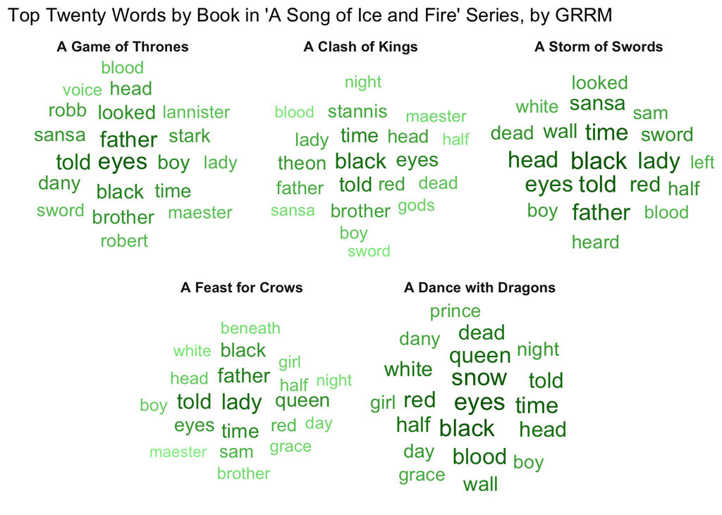

```r
#### Obtaining most-used words by book
top_100_words <- asoiaf_wordcount_clean %>%

  ## Removing unnecessary words like titles and names of characters
  dplyr::filter(word != "lord") %>%
  dplyr::filter(word != "jon") %>%
  dplyr::filter(word != "ned") %>%
  dplyr::filter(word != "ser") %>%
  dplyr::filter(word != "tyrion") %>%
  dplyr::filter(word != "jaime") %>%
  dplyr::filter(word != "catelyn") %>%
  dplyr::filter(word != "bran") %>%
  dplyr::filter(word != "cersei") %>%
  dplyr::filter(word != "brienne") %>%
  dplyr::filter(word != "arya") %>%
  dplyr::filter(word != "hand") %>%
  dplyr::filter(word != "king") %>%
  dplyr::filter(word != "jo") %>%

  ## Grouping by book for word cloud plot
  group_by(book) %>%

  ## Arranging words in increasing order
  arrange(-n) %>%

  ## Getting top 20 words by count (per book)
  slice(1:20) %>%

  ## Removing leftover groups
  ungroup()

## Creating my word cloud for each book in the series
series_cloud <- ggplot(data = top_100_words, aes(label = word)) +
  geom_text_wordcloud(aes(color = n, size = n), shape = "diamond") +
  scale_size_area(max_size = 6) +
  scale_color_gradientn(colors = c("lightgreen", "forestgreen", "darkgreen")) +
  theme_minimal()

## Creating a design to format the facets
design <- c(
  "
  AABBCC
  #DDEE#
  "
)

## Creating a theme to highlight the book names
strips <- strip_themed(
  text_x = elem_list_text(face = "bold", size = 10)
)

## Adding my themes and title to the plot
series_cloud + ggh4x::facet_manual(~book, design = design, strip = strips) +
  ggtitle("Top Twenty Words by Book in 'A Song of Ice and Fire' Series, by GRRM")
```

## 4 Sentiment Analysis

### 4.1 Obtaining sentiments for each book and chapter

```r
#### Sentiment analysis by book ####
## Obtaining sentiments
bing_lex <- get_sentiments(lexicon = "bing")

## Assigning each word to a sentiment
asoiaf_book_bing <- asoiaf_words %>%
  inner_join(bing_lex, by = 'word')

## Summarizing sentiments by both index and book
bing_counts <- asoiaf_book_bing %>%
  group_by(book, index, sentiment) %>%
  summarize(n = n()) %>%
  mutate(sentiment = case_when(
    str_detect(sentiment, "positive") ~ "Positive",
    str_detect(sentiment, "negative") ~ "Negative"
    ))

#### Sentiment analysis by character ####

## Removing stop words
asoiaf_chapter_wordcount_clean <- asoiaf_chapter_wordcount %>%
  anti_join(stop_words, by = 'word')

## Combining the bing sentiment lexicon with the chapters df
asoiaf_chap_bing <- asoiaf_chapter_wordcount_clean %>%
  inner_join(bing_lex, by = 'word')

## Grouping to sort by relevant characters and facet by book
asoiaf_chap_wordcount_bing <- asoiaf_chap_bing %>%
  group_by(index, character, sentiment, book, index_total) %>%
  summarize(n = n())

## Creating a baseline for sentiment analysis of positive/negative
asoiaf_bing_log_ratio_book <- asoiaf_book_bing %>%
  summarize(n_pos = sum(sentiment == 'positive'),
            n_neg = sum(sentiment == 'negative'),
            log_ratio = log(n_pos / n_neg))

## Ordering chapter indices by occurrence rather than alphabetically
asoiaf_book_bing$index <- fct_inorder(asoiaf_book_bing$index) %>% fct_rev()
asoiaf_book_bing$index_total <- fct_inorder(asoiaf_book_bing$index_total) %>% fct_rev()

# Find the log ratio score by chapter:
asoiaf_bing_log_ratio_chap <- asoiaf_book_bing %>%
  group_by(index_total, character, book, index) %>%
  summarize(n_pos = sum(sentiment == 'positive'),
            n_neg = sum(sentiment == 'negative'),
            log_ratio = log(n_pos / n_neg)) %>%
  mutate(log_ratio_adjust = log_ratio - asoiaf_bing_log_ratio_book$log_ratio) %>%
  mutate(pos_neg = ifelse(log_ratio_adjust > 0, 'Positive', 'Negative'))
```

### 4.2 Sentiment Analysis of series

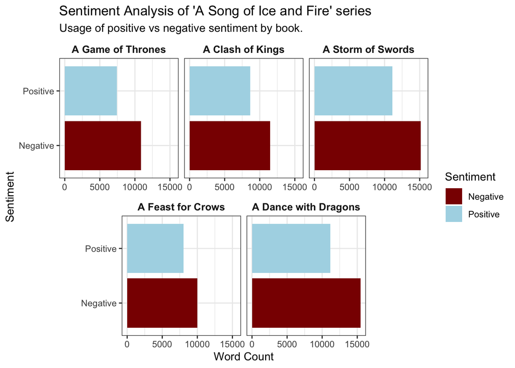

```r
## Analyzing overall sentiment of each book
sentiment_series <- ggplot(data = bing_counts, aes(y = sentiment, x = n)) +
  geom_col(aes(fill = sentiment)) +
  scale_fill_manual(values = c("Positive" = "lightblue", "Negative" = "darkred")) +
  theme_bw() +
  labs(x = "Word Count", y = "Sentiment", fill = "Sentiment", subtitle = "Usage of positive vs negative sentiment by book.")

## Designing strips
strips <- strip_themed(
  text_x = elem_list_text(face = "bold", size = 10),
  background_x = element_blank()
)

## Adding facet to plot
sentiment_series + ggh4x::facet_manual(~book, design = design, strip = strips) +
  ggtitle("Sentiment Analysis of 'A Song of Ice and Fire' series")
```

### 4.3 Sentiment Analysis of Jon Snow’s character across the series

[figure not shown]

```r
asoiaf_bing_log_ratio_jon <- asoiaf_bing_log_ratio_chap %>%
  filter(character == "JON")

jon <- ggplot(data = asoiaf_bing_log_ratio_jon,
       aes(x = log_ratio_adjust,
           y = as.factor(index_total),
           fill = pos_neg)) +
           # y = fct_rev(as.factor(chapter)))) +
  geom_col() +
  labs(x = 'Language Usage',
       y = 'Chapter', fill = "Language") +
  scale_fill_manual(values = c('Positive' = 'lightblue', 'Negative' = 'darkred')) +
  theme_minimal() +
  labs(title = "Sentiment Analysis of Jon Snow in ASOIAF", subtitle = "Jon Snow's word usage across the series, with chapters\ngrouped by book they appear in.") +
  facet_grid(rows = vars(book), scales = "free_y", space = "free_y") +
  theme(panel.spacing = unit(0, "lines"),
        strip.background = element_rect(fill = "white"))

# Calling it
jon
```

### 4.4 Sentiment Analysis of Daenerys Targaryen’s character across the series

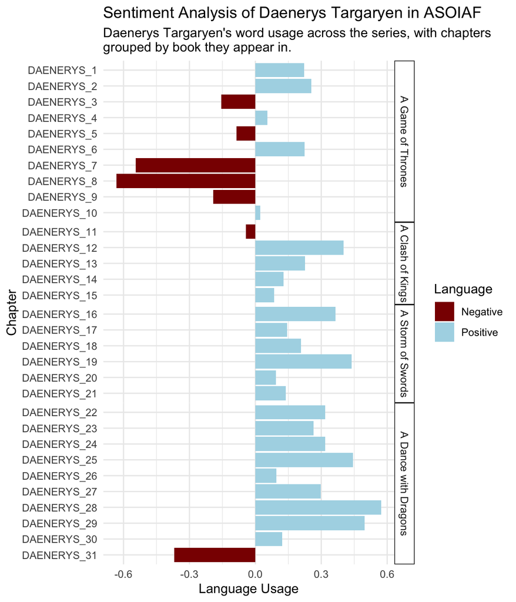

```r
asoiaf_bing_log_ratio_dany <- asoiaf_bing_log_ratio_chap %>%
  filter(character == "DAENERYS")

dany <- ggplot(data = asoiaf_bing_log_ratio_dany,
       aes(x = log_ratio_adjust,
           y = as.factor(index_total),
           fill = pos_neg)) +
           # y = fct_rev(as.factor(chapter)))) +
  geom_col() +
  labs(x = 'Language Usage',
       y = 'Chapter', fill = "Language") +
  scale_fill_manual(values = c('Positive' = 'lightblue', 'Negative' = 'darkred')) +
  theme_minimal() +
  labs(title = "Sentiment Analysis of Daenerys Targaryen in ASOIAF", subtitle = "Daenerys Targaryen's word usage across the series, with chapters\ngrouped by book they appear in.") +
  facet_grid(rows = vars(book), scales = "free_y", space = "free_y") +
  theme(panel.spacing = unit(0, "lines"),
        strip.background = element_rect(fill = "white"))

# Saving my plot
ggsave(here::here("data", "Daenerys_sentiment.jpg"), dany)

# Calling it
dany
```